# BioCro - Exploration

### Understanding NoAA

[figure not shown]

NoAA Weather Forecast Skill

- According to the graph, forecast skill of the Global Forecast system in the NoAA weather graph is defined as a quantity given by 100*(1 - S1/70) where skill (S1) is based on mean error of the 500 mb heights in the forecasts relative to radiosonde measurements over North America.
- It is said that they are using S1 as mean error. However, given the way the values are all positive, it is not so clear that they are using mean error as mean error can be positive or negative.
- Plausible skill measures: RMSE, MAE are some of the skill measures that one can consider. Chi-square test is often used for goodness of fit testing when the data is divided into groups (or) for a discrete case. In our case too, can we create groups for comparison?

### Climate Data that was provided

#### Solutions:

- Use climate16, climate17 separately for these. Include an indicator while graphing and caculating MAE, MAPE and other statistics.

### BioCro Models Run:

#### Sorghum Models Run:

Tri-linear model run.

[output not shown]

### Real Data (Yield from various sources)

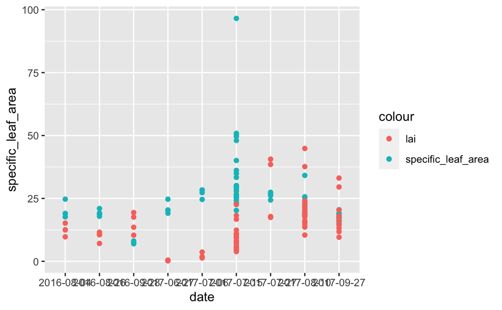

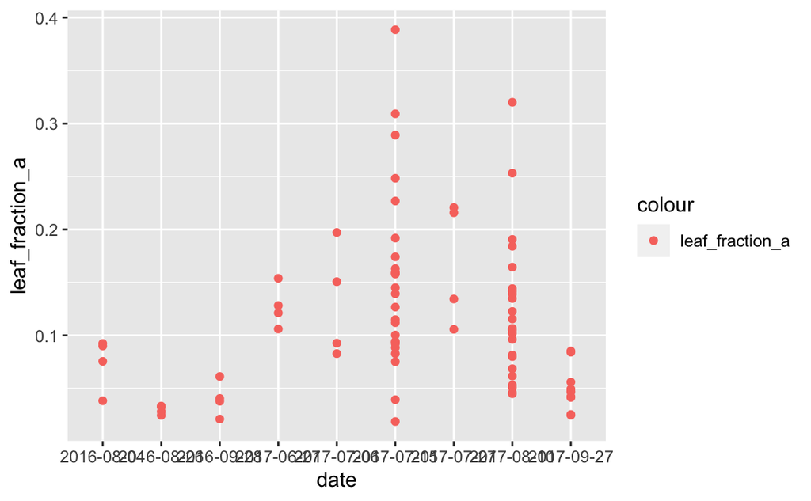

The data provided in “biomass yield” is from 2016 and 2017. Furthermore, there are three sites and also sometimes datapoints from different phenotypes, information of which is not important or provided. The three data changes required in cleaning are separation based on year, modification of date to “doy” for relevant comparison, and evaluating yield in the appropriate units (metric system).

```
[1] "RMSE_yield: 24.93 MAE_yield: 16.9 MAPE_yield: 515.79 Chi Square_yield: 622.89 \n RMSE_lai: 5.46 MAE_lai: 4.71 MAPE_lai: 46.04 Chi Square_lai: 20.97 MDistance: 643.86"
```

```
Removed 2 rows containing missing values (geom_point).
```

## Logistic Model: